# tfm 2023-2024, social analysis of Italy and Spain

Nadia Napolano

2024-06-14

These are all the libraries that are going to be used for the analysis.

```r
library(readxl)
library(ggplot2)
library(dplyr)
library(RColorBrewer)
library(mapSpain)
library(sf)
library(cowplot)
library(tidyverse)
library(plm)
library(car)
library(ggplot2)
library(lmtest)
library(pcse)
library(tseries)
library(sandwich)
library(ggrepel)
library(stringr)
library(ggthemes)
library(rnaturalearth)
```

Let’s start adding the data.

```r
library(readxl)
data <- read_excel("C:/Users/utente/Desktop/Nadia Napolano task 1,,_files/data_output.xlsx")

# Filter the data where TIME_PERIOD is less than 2021
data <- data |>
  filter(TIME_PERIOD < 2021)
```

## descriptive analysis

Let’s see if with data visualization we can find any insight about the situation of tho countries during the last 12 years. In the first part i prefer to split the data set to compare the italian and spanish situation. Later I will try to observe the social situation of the countries in a cohesive way.

```r
# let's get the name of each region
unique(data$region)
```

```
##  [1] "Abruzzo"                      "Andalucía"
##  [3] "Aragón"                       "Asturias (principado de)"
##  [5] "Balears (illes)"              "Basilicata"
##  [7] "Calabria"                     "Campania"
##  [9] "Canarias"                     "Cantabria"
## [11] "Castilla - La mancha"         "Castilla y león"
## [13] "Cataluña"                     "Comunidad valenciana"
## [15] "Emilia Romagna"               "Extremadura"
## [17] "Friuli Venezia Giulia"        "Galicía"
## [19] "Lazio"                        "Liguria"
## [21] "Lombardia"                    "Madrid (comunidad de)"
## [23] "Marche"                       "Molise"
## [25] "Murcia (region de)"           "Navarra (comunidad foral de)"
## [27] "Pais vasco"                   "Piemonte"
## [29] "Provincia Autonoma Bolzano"   "Provincia Autonoma Trento"
## [31] "Puglia"                       "Rioja (la)"
## [33] "Sardegna"                     "Sicilia"
## [35] "Toscana"                      "Umbria"
## [37] "Valle d'Aosta"                "Veneto"
```

```r
#in this part i need to change the names to make them equivalent to tha packages that i am going to use later
data$region <- gsub("Asturias \\(principado de\\)", "Principado de Asturias", data$region)
data$region <- gsub("Balears \\(illes\\)", "Illes Balears", data$region)
data$region <- gsub("Castilla - La mancha", "Castilla-La Mancha", data$region)
data$region <- gsub("Castilla y león", "Castilla y León", data$region)
data$region <- gsub("Comunidad valenciana", "Comunidad Valenciana", data$region)
data$region <- gsub("Galicía", "Galicia", data$region)
data$region <- gsub("Madrid \\(comunidad de\\)", "Comunidad de Madrid", data$region)
data$region <- gsub("Murcia \\(region de\\)", "Región de Murcia", data$region)
data$region <- gsub("Navarra \\(comunidad foral de\\)", "Comunidad Foral de Navarra", data$region)
data$region <- gsub("Pais vasco", "País Vasco", data$region)
data$region <- gsub("Rioja \\(la\\)", "La Rioja", data$region)
data <- data |>
  rename(CCAA = region)
```

let’s separe the regions

```r
# Create a vector with the names of the Italian regions
italian_regions <- c("Abruzzo", "Basilicata", "Calabria", "Campania", "Emilia Romagna",
 "Friuli Venezia Giulia", "Lazio", "Liguria", "Lombardia", "Marche", "Molise", "Piemonte", "Provincia Autonoma Bolzano", "Provincia Autonoma Trento",
"Puglia", "Sardegna", "Sicilia", "Toscana", "Umbria", "Valle d'Aosta", "Veneto")

# Create a vector with the names of the Spanish regions
spanish_regions <- c("País Vasco", "Castilla-La Mancha", "Comunidad Valenciana", "Andalucía",  "Castilla y León", "Extremadura", "Illes Balears", "Cataluña", "Galicia",
 "Aragón", "La Rioja", "Comunidad de Madrid", "Región de Murcia",  "Comunidad Foral de Navarra", "Principado de Asturias", "Canarias", "Cantabria")

# Filter the dataset for Italian regions
data_italy <- data |>  filter(CCAA %in% italian_regions)

# Filter the dataset for Spanish regions
data_spain <- data |>  filter(CCAA %in% spanish_regions)
```

```r
#these are all the information that I get from my dataset
names(data_spain)
```

```
##  [1] "TIME_PERIOD"
##  [2] "CCAA"
##  [3] "early_leaver_educ"
##  [4] "suicides"
##  [5] "gdp regione"
##  [6] "emergency care access per 1000 inhabitants"
##  [7] "employment_value"
##  [8] "gender_gap_ind"
##  [9] "inequality80_20"
## [10] "not_work_or_study"
## [11] "family_income"
## [12] "unemployment"
## [13] "risk_poverty"
```

### Number of suicides in Spain

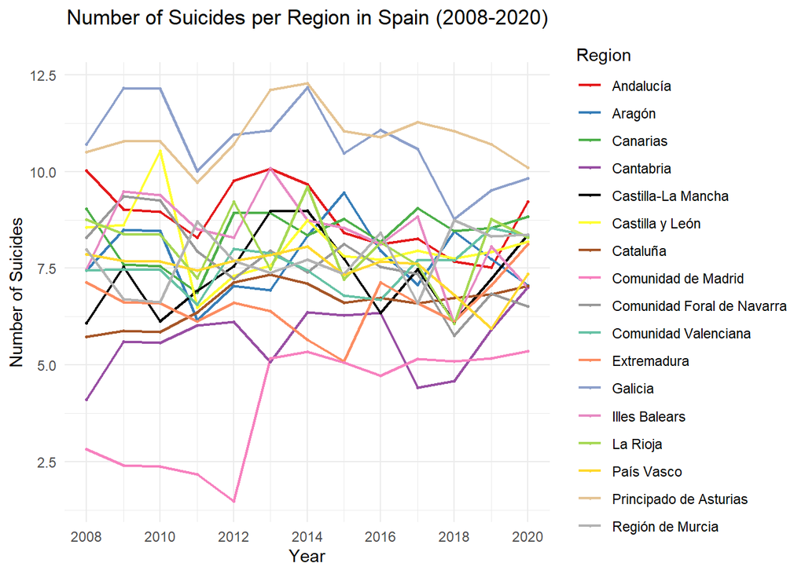

```r
# Create the color palette
palette <- c("#E41A1C", "#377EB8", "#4DAF4A", "#984EA3", "black",
             "#FFFF33", "#A65628", "#F781BF", "#999999", "#66C2A5",
             "#FC8D62", "#8DA0CB", "#E78AC3", "#A6D854", "#FFD92F",
             "#E5C494", "#B3B3B3")

# Create the graph
ggplot(data_spain, aes(x = TIME_PERIOD, y = suicides, color = CCAA)) +
  geom_line(size = 0.8) +
  geom_point(size = 0.5) +
  scale_color_manual(values = palette) +
  scale_x_continuous(breaks = seq(min(data_spain$TIME_PERIOD), max(data_spain$TIME_PERIOD), by = 2)) +
  labs(title = "Number of Suicides per Region in Spain (2008-2020)",
       subtitle = "",
       x = "Year",
       y = "Number of Suicides",
       color = "Region") +
  theme_minimal() +
  theme(plot.title = element_text(hjust = 0.5),
        plot.subtitle = element_text(hjust = 0.5))
```

In this graph it is possible to observe the behaviour of the number of suicides for each region in spain

Let’s try to compare large and small cities

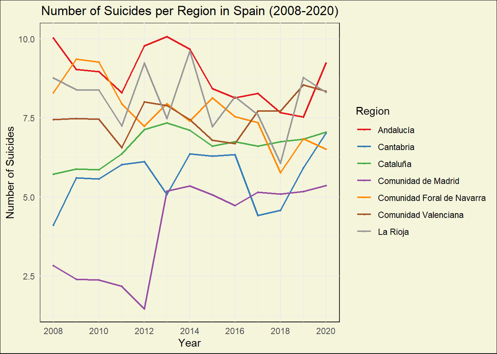

```r
# filtering the regions i am more interested to analyse
regions <- c("Andalucía", "Comunidad de Madrid", "Cataluña", "Comunidad Valenciana",
             "La Rioja", "Comunidad Foral de Navarra", "Cantabria", "Asturias")
data_spain_filter <- data_spain |>
  filter(CCAA %in% regions)

#choosing the colour palette
palette <- c("#E41A1C", "#377EB8", "#4DAF4A", "#984EA3",
             "darkorange", "#A65628",  "#999999", "#66C2A5")

# Creating the graph
ggplot(data_spain_filter, aes(x = TIME_PERIOD, y = suicides, color = CCAA)) +
  geom_line(size = 0.8) +
  geom_point(size = 0.5) +
  scale_color_manual(values = palette) +
  scale_x_continuous(breaks = seq(min(data_spain_filter$TIME_PERIOD), max(data_spain_filter$TIME_PERIOD), by = 2)) +
  labs(title = "Number of Suicides per Region in Spain (2008-2020)",
       x = "Year",
       y = "Number of Suicides",
       color = "Region") +
  theme_minimal() +
  theme(
    plot.title = element_text(hjust = 0.5),
    plot.subtitle = element_text(hjust = 0.5),
    panel.background = element_rect(fill = "beige"),
    plot.background = element_rect(fill = "beige")
  )
```

### Unemployment in Spain

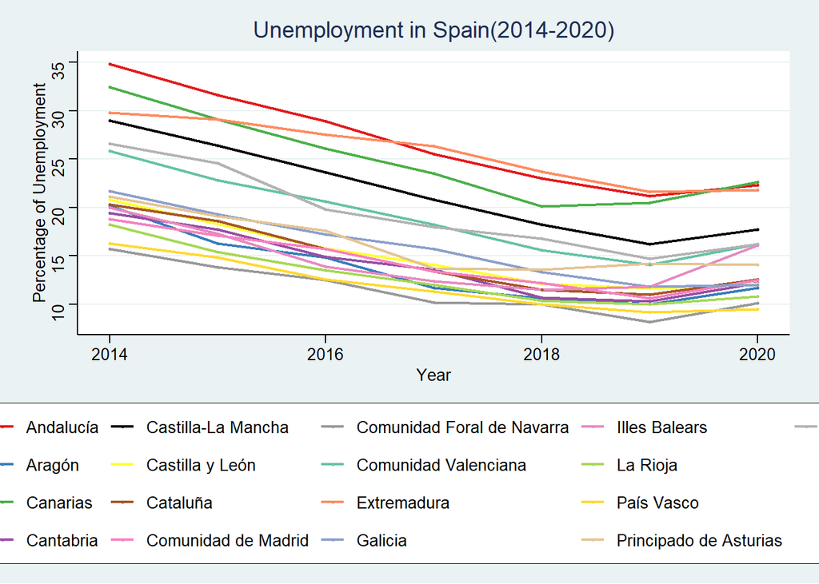

```r
# i need to filter the time period, because some data are missing
data_spain_filter <- data_spain |>
  filter( TIME_PERIOD >= 2014, TIME_PERIOD<=2020)

# colour palette
palette <- c("#E41A1C", "#377EB8", "#4DAF4A", "#984EA3", "black",
             "#FFFF33", "#A65628", "#F781BF", "#999999", "#66C2A5",
             "#FC8D62", "#8DA0CB", "#E78AC3", "#A6D854", "#FFD92F",
             "#E5C494", "#B3B3B3")

# Creating the graph
ggplot(data_spain_filter, aes(x = TIME_PERIOD, y = unemployment, color = CCAA)) +
  geom_line(size = 0.8) +
  geom_point(size = 0.5) +
  scale_color_manual(values = palette) +
  scale_x_continuous(breaks = seq(min(data_spain_filter$TIME_PERIOD), max(data_spain_filter$TIME_PERIOD), by = 2)) +
  labs(title = "Unemployment in Spain(2014-2020)",
       x = "Year",
       y = "Percentage of Unemployment",
       color = "Region") +
  theme_stata() + # Applica il tema Stata
  theme(plot.title = element_text(hjust = 0.5),
        plot.subtitle = element_text(hjust = 0.5))
```

### gender gap

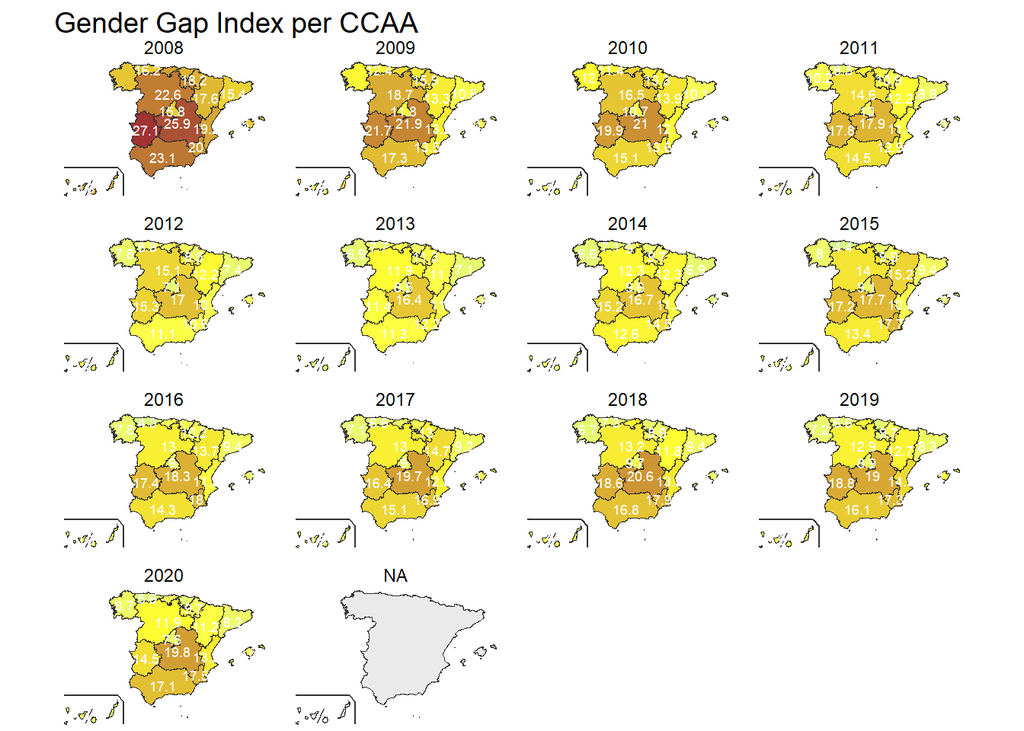

```r
# getting geo data
esp_can <- esp_get_country()
can_prov <- esp_get_can_provinces()
can_box <- esp_get_can_box()
munic <- esp_get_munic()
ccaa <- esp_get_ccaa()

mapa <- data_spain |>
  select(CCAA, gender_gap_ind, TIME_PERIOD) |>
  distinct(CCAA, TIME_PERIOD, .keep_all = TRUE)

# left join to get the correspondance between the regions name in the map and in the dataset
mapa <- ccaa |>
  left_join(mapa, by = c("nuts2.name" = "CCAA"))

#creating the map
p1 <- ggplot(esp_can) +
  geom_sf(color = "black", size = 0.7) +
  geom_sf(data = can_prov) +
  geom_sf(data = can_box) +
  geom_sf(data = mapa, aes(fill = gender_gap_ind), color = "black", size = 0.3) +
  annotate("rect", xmin = -Inf, xmax = Inf, ymin = -Inf, ymax = Inf, alpha = 0.2, fill = "white") +
  geom_sf_text(data = mapa, aes(label = round(gender_gap_ind, 2), color = ifelse(gender_gap_ind > 0.5, "white", "black")),
               size = 2.4, check_overlap = TRUE, nudge_y = -0.03) +
  theme_void() +
  labs(title = "Gender Gap Index per CCAA") +
  theme(
    legend.position = "none",
    plot.title = element_text(family = "Calibri", size = 14),
    text = element_text(family = "Calibri"),
    plot.background = element_rect(fill = "white", color = NA),
    panel.background = element_rect(fill = "white", color = NA)
  ) +
  coord_sf() +
  scale_fill_gradient2(low = "lightgreen", mid = "yellow", high = "darkred", midpoint = median(data_spain$gender_gap_ind, na.rm = TRUE)) +
  scale_color_identity() +
  facet_wrap(~ TIME_PERIOD)  # Creatingfacet per year
# printing the graph
print(p1)
```

```r
# get geo data
esp_can <- esp_get_country()
can_prov <- esp_get_can_provinces()
can_box <- esp_get_can_box()
ccaa <- esp_get_ccaa()

# filtering
data_spain_filtered <- data_spain |>
  filter(TIME_PERIOD %in% c(2008, 2012, 2016, 2020))

# Transform column names to lowercase and replace spaces with underscores
data_spain_filtered <- data_spain_filtered |>
  rename_with(~ str_replace_all(str_to_lower(.), " ", "_"))

# Select the columns
mapa <- data_spain_filtered |>
  select(ccaa,`emergency_care_access_per_1000_inhabitants`, time_period) |>
  distinct(ccaa, time_period, .keep_all = TRUE)

# looking for NAs
print("Unique TIME_PERIOD values before join:")
```

```
## [1] "Unique TIME_PERIOD values before join:"
```

```r
print(unique(mapa$time_period))
```

```
## [1] 2008 2012 2016 2020
```

```r
# left join the data from the two datasets
mapa <- ccaa %>%
  left_join(mapa, by = c("nuts2.name" = "ccaa"))

# verify again
print("Unique TIME_PERIOD values after join:")
```

```
## [1] "Unique TIME_PERIOD values after join:"
```

```r
print(unique(mapa$time_period))
```

```
## [1] 2008 2012 2016 2020   NA
```

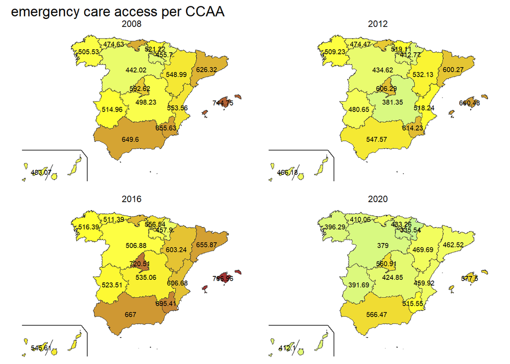

```r
# filtering
mapa <- mapa |>
  filter(time_period %in% c(2008, 2012, 2016, 2020))

# Creating the map
p1 <- ggplot() +
  geom_sf(data = esp_can, color = "black", size = 0.7) +
  geom_sf(data = can_prov) +
  geom_sf(data = can_box) +
  geom_sf(data = mapa, aes(fill = emergency_care_access_per_1000_inhabitants), color = "black", size = 0.3) +
  annotate("rect", xmin = -Inf, xmax = Inf, ymin = -Inf, ymax = Inf, alpha = 0.2, fill = "white") +
  geom_sf_text(data = mapa, aes(label = round(emergency_care_access_per_1000_inhabitants, 2), color = ifelse(emergency_care_access_per_1000_inhabitants > 0.5, "black", "purple")),
               size = 2.4, check_overlap = TRUE, nudge_y = -0.03) +
  theme_void() +
  labs(title = "emergency care access per CCAA") +
  theme(
    legend.position = "none",
    plot.title = element_text(family = "Calibri", size = 14),
    text = element_text(family = "Calibri"),
    plot.background = element_rect(fill = "white", color = NA),
    panel.background = element_rect(fill = "white", color = NA)
  ) +
  coord_sf() +
  scale_fill_gradient2(low = "lightgreen", mid = "yellow", high = "darkred", midpoint = median(data_spain_filtered$emergency_care_access_per_1000_inhabitants, na.rm = TRUE)) +
  scale_color_identity() +
  facet_wrap(~ time_period, ncol = 2)  # Creare i facet per TIME_PERIOD

# Stampare il grafico
print(p1)
```

```r
# Load geographic data
esp_can <- esp_get_country()
can_prov <- esp_get_can_provinces()
can_box <- esp_get_can_box()
regions <- esp_get_ccaa()


# Select the necessary columns and remove duplicates
map_data <- data_spain_filtered |>
  select(ccaa, employment_value, time_period) |>
  distinct(ccaa, time_period, .keep_all = TRUE)

# Check for NA in the time_period field before joining
print("Unique time_period values before join:")
```

```
## [1] "Unique time_period values before join:"
```

```r
print(unique(map_data$time_period))
```

```
## [1] 2008 2012 2016 2020
```

```r
# Join the geographic data with the gender gap data
map_data <- regions  |>
  left_join(map_data, by = c("nuts2.name" = "ccaa"))

# Check for NA in the time_period field after joining
print("Unique time_period values after join:")
```

```
## [1] "Unique time_period values after join:"
```

```r
print(unique(map_data$time_period))
```

```
## [1] 2008 2012 2016 2020   NA
```

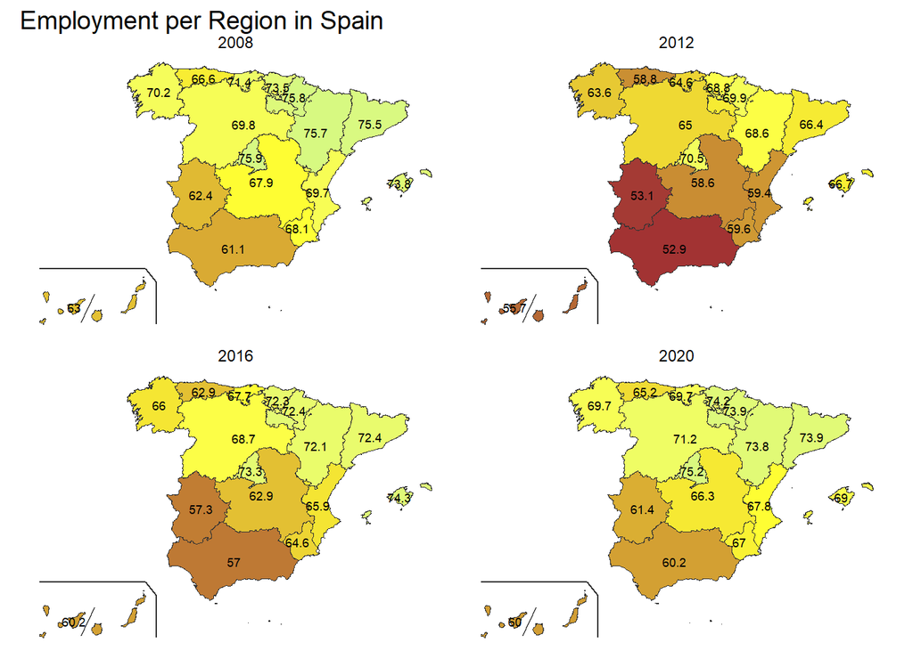

```r
# Filter the data again after the join for safety
map_data <- map_data |>
  filter(time_period %in% c(2008, 2012, 2016, 2020))

# Create the map
p1 <- ggplot() +
  geom_sf(data = esp_can, color = "black", size = 0.7) +
  geom_sf(data = can_prov) +
  geom_sf(data = can_box) +
  geom_sf(data = map_data, aes(fill = employment_value), color = "black", size = 0.3) +
  annotate("rect", xmin = -Inf, xmax = Inf, ymin = -Inf, ymax = Inf, alpha = 0.2, fill = "white") +
  geom_sf_text(data = map_data, aes(label = round(employment_value, 2), color = ifelse(employment_value > 0.5, "black", "black")),
               size = 2.4, check_overlap = TRUE, nudge_y = -0.03) +
  theme_void() +
  labs(title = "Employment per Region in Spain") +
  theme(
    legend.position = "none",
    plot.title = element_text(family = "Calibri", size = 14),
    text = element_text(family = "Calibri"),
    plot.background = element_rect(fill = "white", color = NA),
    panel.background = element_rect(fill = "white", color = NA)
  ) +
  coord_sf() +
  scale_fill_gradient2(low = "darkred", mid = "yellow", high = "lightgreen", midpoint = median(data_spain_filtered$employment_value, na.rm = TRUE)) +
  scale_color_identity() +
  facet_wrap(~ time_period, ncol = 2)  # Create facets for time_period

# Print the plot
print(p1)
```

## early leaver education

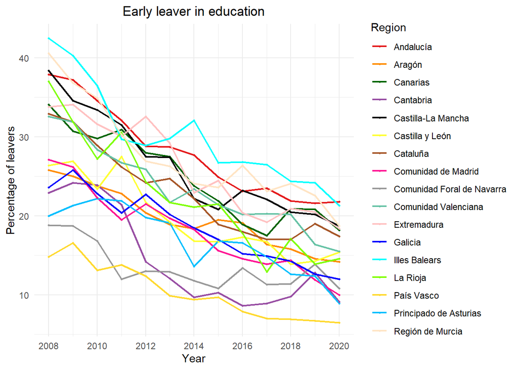

```r
# Ensure that TIME_PERIOD is numeric
data_spain$TIME_PERIOD <- as.numeric(data_spain$TIME_PERIOD)


# colour palette
palette <- c("#E41A1C", "darkorange", "darkgreen", "#984EA3", "black",
             "#FFFF33", "#A65628", "deeppink1", "#999999", "#66C2A5",
             "rosybrown1", "blue1", "cyan", "chartreuse1", "#FFD92F",
             "deepskyblue", "bisque1")

# Creating the graph
ggplot(data_spain, aes(x = TIME_PERIOD, y = early_leaver_educ, color = CCAA)) +
  geom_line(size = 0.8) + geom_point(size = 0.5) +
  scale_x_continuous(breaks = seq(min(data_spain$TIME_PERIOD), max(data_spain$TIME_PERIOD), by = 2))+
  scale_color_manual(values = palette) +  labs(title = "Early leaver in education",
       x = "Year",
       y = "Percentage of leavers",
       color = "Region") +
  theme_minimal() +
  theme(plot.title = element_text(hjust = 0.5),
        plot.subtitle = element_text(hjust = 0.5))
```

### Not working and not studying

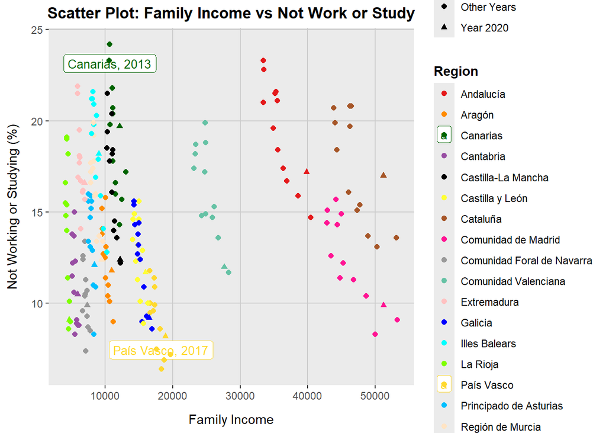

```r
# Create a new column to identify if the TIME_PERIOD is 2020 and label it appropriately
data_spain <- data_spain |>
  mutate(is_2020_label = ifelse(TIME_PERIOD == 2020, "Year 2020", "Other Years"))

# Filter out the extremes for labeling
highest <- data_spain |>
  filter(not_work_or_study == max(not_work_or_study))
lowest <- data_spain |>
  filter(not_work_or_study == min(not_work_or_study))
extremes <- rbind(highest, lowest)

# Create the scatter plot to see the relationship
scatter_plot <- ggplot(data_spain, aes(x = family_income, y = not_work_or_study, color = CCAA)) +
  geom_label_repel(data = extremes, aes(label = paste(CCAA, TIME_PERIOD, sep = ", ")), size = 3.5, box.padding = 0.5, point.padding = 0.5) +
  geom_point(aes(shape = is_2020_label), size = 1.7) +
  scale_shape_manual(values = c("Other Years" = 16, "Year 2020" = 17)) + # Use 16 (circle) for other years and 17 (triangle) for 2020
  scale_color_manual(values = palette) + # Use the custom defined palette
  labs(title = "Scatter Plot: Family Income vs Not Work or Study",
       x = "Family Income",
       y = "Not Working or Studying (%)",
       color = "Region",
       shape = "Year") + # Update the legend title for shapes
  theme(
    plot.title = element_text(hjust = 0.5, face = "bold"),
    legend.position = "right",
    legend.title = element_text(face = "bold"),
    panel.grid.major = element_line(color = "grey80"),
    panel.grid.minor = element_blank(),
    axis.title.x = element_text(margin = margin(t = 10)),
    axis.title.y = element_text(margin = margin(r = 10))
  )

# Display the plot
scatter_plot
```

i am really proud of this graph :)

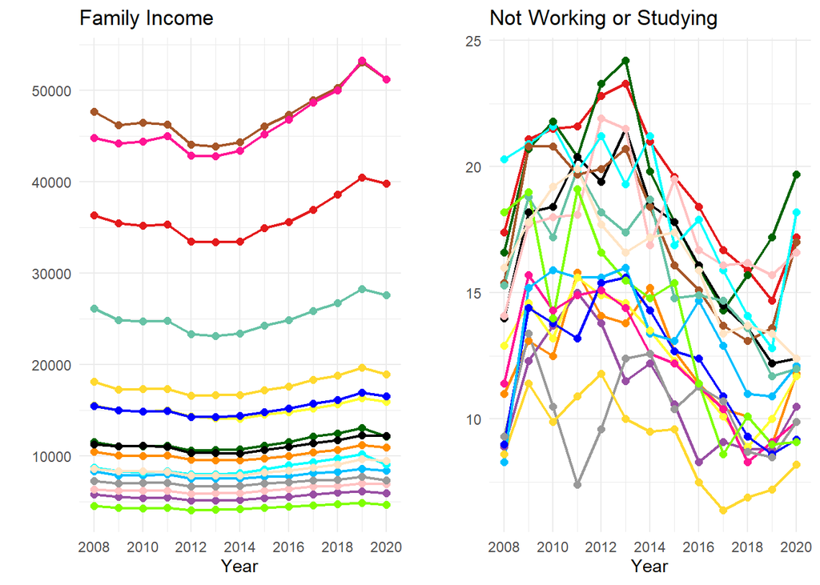

```r
# Create the line plot for not_work_or_study
line_plot_not_work_or_study <- ggplot(data_spain, aes(x = TIME_PERIOD, y = not_work_or_study, color = CCAA)) +
  geom_line(size = 0.8) +
  geom_point(size = 2) +
  scale_color_manual(values = palette) +
  scale_x_continuous(breaks = seq(min(data_spain$TIME_PERIOD), max(data_spain$TIME_PERIOD), by = 2))+
  labs(title = "Not Working or Studying",
       x = "Year",
       y = "",
       color = "Region") +
  theme_minimal()

# Create the line plot for family_income
line_plot_family_income <- ggplot(data_spain, aes(x = TIME_PERIOD, y = family_income, color = CCAA)) +
  geom_line(size = 0.8) +
  geom_point(size = 2) +
  scale_color_manual(values = palette) +
  scale_x_continuous(breaks = seq(min(data_spain$TIME_PERIOD), max(data_spain$TIME_PERIOD), by = 2))+
  labs(title = "Family Income",
       x = "Year",
       y = "",
       color = "Region") +
  theme_minimal()

# Estrai la legenda da uno dei grafici
legend <- get_legend(line_plot_family_income)
# Rimuovi la legenda dai grafici originali
line_plot_family_income <- line_plot_family_income + theme(legend.position = "none")
line_plot_not_work_or_study <- line_plot_not_work_or_study + theme(legend.position = "none")

combined_plots <- plot_grid(
  line_plot_family_income,
  line_plot_not_work_or_study,
  ncol = 2,
  align = 'v'
)

# Aggiungi la legenda a destra dei grafici combinati
final_plot <- plot_grid(
  combined_plots,
  ncol = 1,
 rel_widths = c(2) # Puoi regolare la larghezza relativa della legenda
)

# Visualizza il grafico finale
print(final_plot)
```

it is a slight perception, but especially in 2020 one can see that the two graphs have an inverse behaviour.

## Analytical part: behavior of the percentage of school dropout and socioeconomic variables

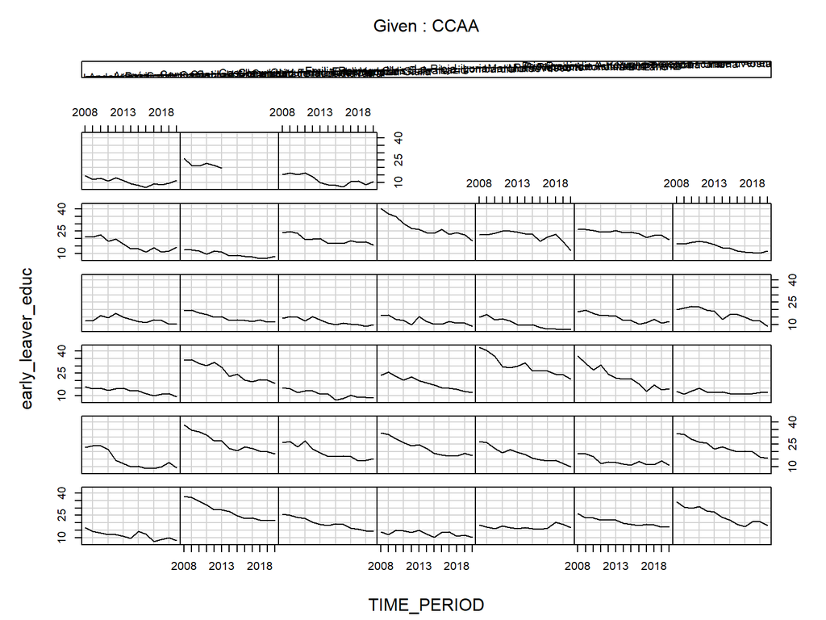

```
##
##  Righe assenti: 475, 476, 477, 478, 479, 480, 481
```

```r
D<-pdata.frame(data, index=c("CCAA", "TIME_PERIOD")) #declare TSCS data, identify unit and time variables
coplot(early_leaver_educ ~ TIME_PERIOD | CCAA, type="l", data=D)
```

The x-axis represents TIME_PERIOD, which appears to range from approximately 2008 to 2020. The y-axis represents early_leaver_educ, with values ranging roughly between 10 and 40. Each horizontal strip (panel) corresponds to a specific region.

The lines within each panel show how early_leaver_educ changes over time for each region.Looking at it we can observe that most regions seem to show a general downward trend in early_leaver_educ over time, indicating that the percentage of early leavers from education is decreasing.

```r
# fixing the columns name to make the analysis easier
data <- data |>
 rename_all(~ gsub(" ", "_", .)) |>
rename_all(tolower)
# printing the names
print(colnames(data))
```

```
##  [1] "time_period"
##  [2] "ccaa"
##  [3] "early_leaver_educ"
##  [4] "suicides"
##  [5] "gdp_regione"
##  [6] "emergency_care_access_per_1000_inhabitants"
##  [7] "employment_value"
##  [8] "gender_gap_ind"
##  [9] "inequality80_20"
## [10] "not_work_or_study"
## [11] "family_income"
## [12] "unemployment"
## [13] "risk_poverty"
```

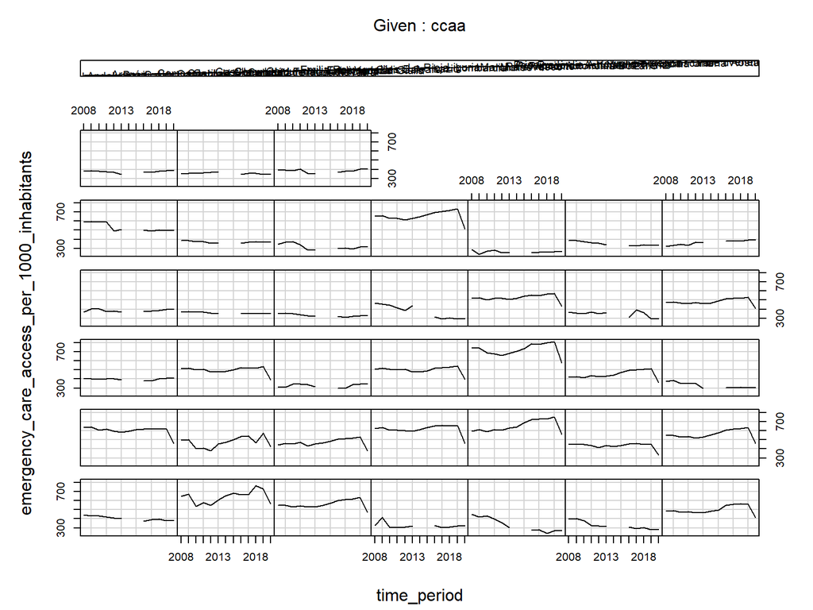

```
##
##  Righe assenti: 7, 8, 46, 47, 59, 60, 72, 73, 189, 190, 215, 216, 267, 268, 280, 281, 293, 294, 306, 307, 319, 320, 345, 346, 371, 372, 384, 385, 397, 398, 423, 424, 436, 437, 449, 450, 462, 463, 475, 476, 488, 489
```

```r
D<-pdata.frame(data, index=c("ccaa", "time_period")) #declare TSCS data, identify unit and time variables

coplot(emergency_care_access_per_1000_inhabitants ~ time_period | ccaa, type="l", data=D)
```

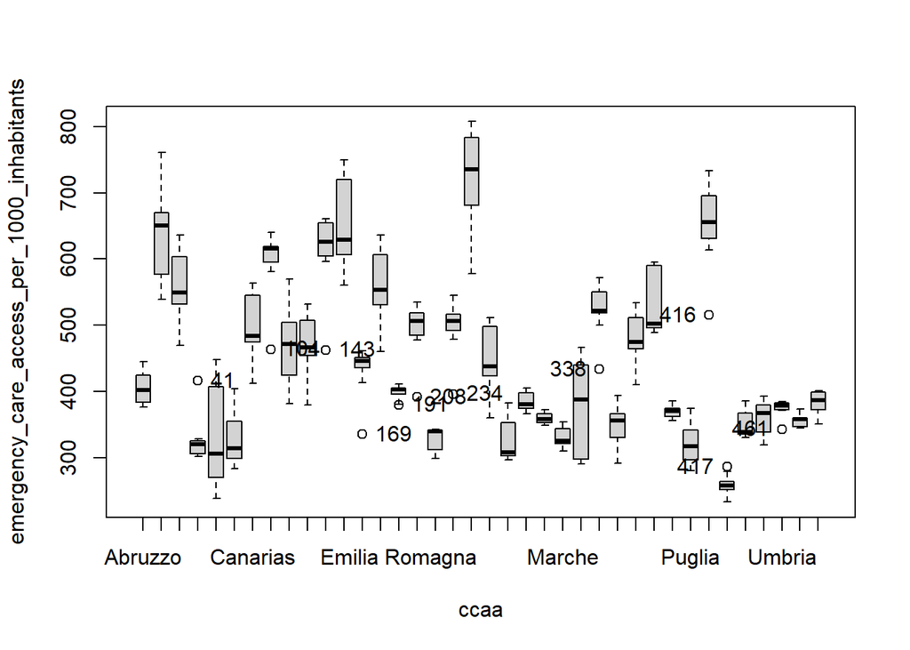

```
##  [1] "41"  "104" "143" "169" "191" "208" "234" "338" "416" "417" "461"
```

```r
scatterplot(emergency_care_access_per_1000_inhabitants ~ ccaa, data=D)
```

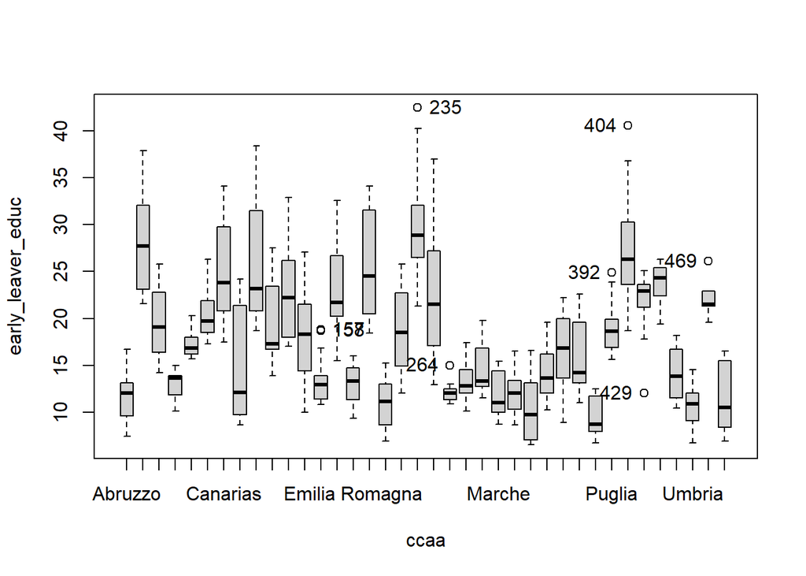

```
## [1] "157" "158" "235" "264" "392" "404" "429" "469"
```

```r
scatterplot(early_leaver_educ ~ ccaa, data=D)
```

this graph enhance how the situation changes in each region

### anova analysis

Next, let’s run an analysis of variance to assess more formally whether this data suffers from unit effects.

```r
anova<-aov(early_leaver_educ ~ ccaa, data=D) #run ANOVA
summary(anova) #view results
```

```
##              Df Sum Sq Mean Sq F value Pr(>F)
## ccaa         37  15978   431.8   24.93 <2e-16 ***
## Residuals   449   7776    17.3
## ---
## Signif. codes:  0 '***' 0.001 '**' 0.01 '*' 0.05 '.' 0.1 ' ' 1
## 7 osservazioni eliminate a causa di valori mancanti
```

The ANOVA results above show a very low p-value, suggesting significant unit effects. This means that there is important variation in school leaving across our 38 regions. This suggests that regular OLS analysis will be biased! let’s estimate it anyway to see the results.

```r
ols<-lm(early_leaver_educ~ gdp_regione + employment_value + inequality80_20 +risk_poverty, data=D)
summary(ols)
```

```
##
## Call:
## lm(formula = early_leaver_educ ~ gdp_regione + employment_value +
##     inequality80_20 + risk_poverty, data = D)
##
## Residuals:
##     Min      1Q  Median      3Q     Max
## -14.932  -3.379  -1.085   3.228  15.495
##
## Coefficients:
##                    Estimate Std. Error t value Pr(>|t|)
## (Intercept)       3.519e+01  5.682e+00   6.193 1.62e-09 ***
## gdp_regione      -2.396e-06  3.518e-06  -0.681    0.496
## employment_value -3.800e-01  6.620e-02  -5.741 2.01e-08 ***
## inequality80_20   2.014e+00  2.820e-01   7.141 5.19e-12 ***
## risk_poverty     -2.281e-01  5.626e-02  -4.054 6.18e-05 ***
## ---
## Signif. codes:  0 '***' 0.001 '**' 0.01 '*' 0.05 '.' 0.1 ' ' 1
##
## Residual standard error: 4.955 on 358 degrees of freedom
##   (131 osservazioni eliminate a causa di valori mancanti)
## Multiple R-squared:  0.3122, Adjusted R-squared:  0.3045
## F-statistic: 40.63 on 4 and 358 DF,  p-value: < 2.2e-16
```

There are two general approaches to dealing with unit effects: 1) Fixed effects models 2) Random effects models

## fixed effects

```r
fe<-plm(early_leaver_educ~ gdp_regione + employment_value + inequality80_20 +risk_poverty, data=D, index=c("ccaa","time_period"), model="within")
#define model, data, unit and time variables, 'within' suggests *fixed effects estimator*
summary(fe)
```

```
## Oneway (individual) effect Within Model
##
## Call:
## plm(formula = early_leaver_educ ~ gdp_regione + employment_value +
##     inequality80_20 + risk_poverty, data = D, model = "within",
##     index = c("ccaa", "time_period"))
##
## Unbalanced Panel: n = 37, T = 3-10, N = 363
##
## Residuals:
##     Min.  1st Qu.   Median  3rd Qu.     Max.
## -8.03792 -1.26267 -0.20334  1.12927 10.04846
##
## Coefficients:
##                     Estimate  Std. Error  t-value Pr(>|t|)
## gdp_regione      -2.2070e-05  2.6969e-05  -0.8184   0.4138
## employment_value -7.0368e-01  6.5053e-02 -10.8169   <2e-16 ***
## inequality80_20   2.3903e-01  2.0407e-01   1.1713   0.2424
## risk_poverty     -1.5593e-01  6.2840e-02  -2.4813   0.0136 *
## ---
## Signif. codes:  0 '***' 0.001 '**' 0.01 '*' 0.05 '.' 0.1 ' ' 1
##
## Total Sum of Squares:    2922.7
## Residual Sum of Squares: 1785.6
## R-Squared:      0.38905
## Adj. R-Squared: 0.31315
## F-statistic: 51.2618 on 4 and 322 DF, p-value: < 2.22e-16
```

Let’s compare this estimate with a dummy variable model, which is estimated simply by running an OLS model and including country dummies:

```r
fe.dummy<-lm(early_leaver_educ~ gdp_regione + employment_value + inequality80_20 +risk_poverty +factor(ccaa)-1, data=D)
summary(fe.dummy)
```

```
##
## Call:
## lm(formula = early_leaver_educ ~ gdp_regione + employment_value +
##     inequality80_20 + risk_poverty + factor(ccaa) - 1, data = D)
##
## Residuals:
##     Min      1Q  Median      3Q     Max
## -8.0379 -1.2627 -0.2033  1.1293 10.0485
##
## Coefficients:
##                                          Estimate Std. Error t value Pr(>|t|)
## gdp_regione                            -2.207e-05  2.697e-05  -0.818   0.4138
## employment_value                       -7.037e-01  6.505e-02 -10.817   <2e-16
## inequality80_20                         2.390e-01  2.041e-01   1.171   0.2424
## risk_poverty                           -1.559e-01  6.284e-02  -2.481   0.0136
## factor(ccaa)Abruzzo                     5.899e+01  4.229e+00  13.950   <2e-16
## factor(ccaa)Andalucía                   7.184e+01  4.065e+00  17.674   <2e-16
## factor(ccaa)Aragón                      7.011e+01  4.525e+00  15.492   <2e-16
## factor(ccaa)Basilicata                  5.691e+01  4.311e+00  13.203   <2e-16
## factor(ccaa)Calabria                    5.573e+01  3.721e+00  14.977   <2e-16
## factor(ccaa)Campania                    6.003e+01  3.808e+00  15.766   <2e-16
## factor(ccaa)Canarias                    6.822e+01  4.038e+00  16.895   <2e-16
## factor(ccaa)Cantabria                   6.074e+01  4.558e+00  13.324   <2e-16
## factor(ccaa)Castilla-La Mancha          7.163e+01  4.203e+00  17.042   <2e-16
## factor(ccaa)Castilla y León             6.840e+01  4.142e+00  16.514   <2e-16
## factor(ccaa)Cataluña                    7.601e+01  5.084e+00  14.952   <2e-16
## factor(ccaa)Comunidad de Madrid         7.278e+01  5.182e+00  14.045   <2e-16
## factor(ccaa)Comunidad Foral de Navarra  6.403e+01  4.742e+00  13.503   <2e-16
## factor(ccaa)Emilia Romagna              6.953e+01  4.459e+00  15.595   <2e-16
## factor(ccaa)Extremadura                 6.859e+01  4.153e+00  16.515   <2e-16
## factor(ccaa)Friuli Venezia Giulia       6.229e+01  4.465e+00  13.951   <2e-16
## factor(ccaa)Galicia                     6.611e+01  4.031e+00  16.400   <2e-16
## factor(ccaa)Illes Balears               7.845e+01  4.684e+00  16.749   <2e-16
## factor(ccaa)La Rioja                    7.136e+01  4.914e+00  14.521   <2e-16
## factor(ccaa)Lazio                       6.561e+01  4.762e+00  13.776   <2e-16
## factor(ccaa)Liguria                     6.451e+01  4.325e+00  14.917   <2e-16
## factor(ccaa)Lombardia                   7.429e+01  8.294e+00   8.958   <2e-16
## factor(ccaa)Marche                      6.346e+01  4.412e+00  14.383   <2e-16
## factor(ccaa)Molise                      5.674e+01  4.455e+00  12.735   <2e-16
## factor(ccaa)País Vasco                  6.114e+01  4.262e+00  14.346   <2e-16
```

[output cut: 46 more lines]

```
## factor(ccaa)Puglia                     ***
## factor(ccaa)Región de Murcia           ***
## factor(ccaa)Sardegna                   ***
## factor(ccaa)Sicilia                    ***
## factor(ccaa)Toscana                    ***
## factor(ccaa)Umbria                     ***
## factor(ccaa)Valle d'Aosta              ***
## factor(ccaa)Veneto                     ***
## ---
## Signif. codes:  0 '***' 0.001 '**' 0.01 '*' 0.05 '.' 0.1 ' ' 1
##
## Residual standard error: 2.355 on 322 degrees of freedom
##   (131 osservazioni eliminate a causa di valori mancanti)
## Multiple R-squared:  0.9833, Adjusted R-squared:  0.9812
## F-statistic: 463.7 on 41 and 322 DF,  p-value: < 2.2e-16
```

the risk of poverty is less significant than before!!

```r
re<-plm(early_leaver_educ ~ gdp_regione + employment_value +
    inequality80_20 + risk_poverty, data=D, index=c("ccaa","time_period"), model="random")
#same logic as FE estimation above, but "random" specifies RE estimator
summary(re)
```

```
## Oneway (individual) effect Random Effect Model
##    (Swamy-Arora's transformation)
##
## Call:
## plm(formula = early_leaver_educ ~ gdp_regione + employment_value +
##     inequality80_20 + risk_poverty, data = D, model = "random",
##     index = c("ccaa", "time_period"))
##
## Unbalanced Panel: n = 37, T = 3-10, N = 363
##
## Effects:
##                  var std.dev share
## idiosyncratic  5.545   2.355 0.241
## individual    17.453   4.178 0.759
## theta:
##    Min. 1st Qu.  Median    Mean 3rd Qu.    Max.
##  0.6905  0.8245  0.8245  0.8234  0.8245  0.8245
##
## Residuals:
##    Min. 1st Qu.  Median    Mean 3rd Qu.    Max.
## -7.8690 -1.6430 -0.2558 -0.0167  1.2071 11.4415
##
## Coefficients:
##                     Estimate  Std. Error  z-value  Pr(>|z|)
## (Intercept)       6.2874e+01  3.8653e+00  16.2663 < 2.2e-16 ***
## gdp_regione      -1.8622e-06  8.9753e-06  -0.2075    0.8356
## employment_value -6.5999e-01  5.0361e-02 -13.1050 < 2.2e-16 ***
## inequality80_20   4.4306e-01  1.9968e-01   2.2189    0.0265 *
## risk_poverty     -2.4763e-01  5.1357e-02  -4.8217 1.424e-06 ***
## ---
## Signif. codes:  0 '***' 0.001 '**' 0.01 '*' 0.05 '.' 0.1 ' ' 1
##
## Total Sum of Squares:    3266
## Residual Sum of Squares: 2080.2
## R-Squared:      0.3632
## Adj. R-Squared: 0.35608
## Chisq: 198.124 on 4 DF, p-value: < 2.22e-16
```

### Fixed or random effects?

One way to check is to run the Hausman test. Here H0 is that the preferred model is RE. The alternative Ha is that it is FE.

```r
library(plm)
phtest(fe,re)
```

```
##
##  Hausman Test
##
## data:  early_leaver_educ ~ gdp_regione + employment_value + inequality80_20 +  ...
## chisq = 8.154, df = 4, p-value = 0.0861
## alternative hypothesis: one model is inconsistent
```

Fixed Effects (FE) and Random Effects (RE) models have some problems too: the first ones can’t estimate effects of variables that don’t change over time, and the second ones assumes unit effects are uncorrelated with predictors. For this reason Beck and Katz (1995) suggested using Ordinary Least Squares (OLS) with corrected standard errors to account for error correlation and autocorrelation. The Panel Corrected Standard Errors (PCSE), only adjusts the standard errors, not the estimated coefficients. Thus,it provides the same coefficients as OLS but with more reliable significance tests.

```r
# Identify the columns to use
cols <- c("early_leaver_educ", "gdp_regione", "employment_value",
          "inequality80_20", "risk_poverty", "ccaa", "time_period")
# removing the NAs
D_clean <- D[complete.cases(D[cols]), ]

# ols model
ols <- lm(early_leaver_educ ~ gdp_regione + employment_value +
          inequality80_20 + risk_poverty, data=D_clean)
summary(ols)
```

```
##
## Call:
## lm(formula = early_leaver_educ ~ gdp_regione + employment_value +
##     inequality80_20 + risk_poverty, data = D_clean)
##
## Residuals:
##     Min      1Q  Median      3Q     Max
## -14.932  -3.379  -1.085   3.228  15.495
##
## Coefficients:
##                    Estimate Std. Error t value Pr(>|t|)
## (Intercept)       3.519e+01  5.682e+00   6.193 1.62e-09 ***
## gdp_regione      -2.396e-06  3.518e-06  -0.681    0.496
## employment_value -3.800e-01  6.620e-02  -5.741 2.01e-08 ***
## inequality80_20   2.014e+00  2.820e-01   7.141 5.19e-12 ***
## risk_poverty     -2.281e-01  5.626e-02  -4.054 6.18e-05 ***
## ---
## Signif. codes:  0 '***' 0.001 '**' 0.01 '*' 0.05 '.' 0.1 ' ' 1
##
## Residual standard error: 4.955 on 358 degrees of freedom
## Multiple R-squared:  0.3122, Adjusted R-squared:  0.3045
## F-statistic: 40.63 on 4 and 358 DF,  p-value: < 2.2e-16
```

```r
# apply pcse function
pcse_results <- pcse(ols, groupN=D_clean$ccaa, groupT=D_clean$time_period, pairwise=TRUE)

#Results
summary(pcse_results)
```

```
##
##  Results:
##
##                       Estimate         PCSE   t value     Pr(>|t|)
## (Intercept)       3.518966e+01 9.954883e+00  3.534914 4.614350e-04
## gdp_regione      -2.396141e-06 1.443825e-06 -1.659579 9.787485e-02
## employment_value -3.800404e-01 1.064305e-01 -3.570784 4.045081e-04
## inequality80_20   2.013950e+00 4.640020e-01  4.340390 1.853182e-05
## risk_poverty     -2.280937e-01 7.458855e-02 -3.058026 2.395666e-03
##
##  ---------------------------------------------
##
## # Valid Obs = 363; # Missing Obs = 7; Degrees of Freedom = 358.
```

An increase in regional GDP (gdp_region) is associated with a slight reduction in the early education drop-out rate. An increase in employment value (employment_value) is associated with a significant reduction in the early education drop-out rate. An increase in inequality (inequality80_20) is associated with a significant increase in the early education drop-out rate. An increase in the risk of poverty (risk_poverty) is associated with a significant reduction in the rate of early school leaving.

PCSE, sadly, cannot deal with the big problem, potentially biasing the estimates – unit effects. So Beck and Katz proposed a lagged dependent variable (LDV) in the OLS model before calculating the PCSE.

```r
D <- D  |>
  group_by(ccaa, time_period) |>
  mutate(l.early_leaver_educ = lag(early_leaver_educ)) |>
  mutate(d.gdp_regione = gdp_regione - lag(gdp_regione)) |>
  mutate(d.employment_value = employment_value - lag(employment_value)) |>
  mutate(d.inequality80_20 = inequality80_20 - lag(inequality80_20)) |>
  mutate(d.risk_poverty = risk_poverty - lag(risk_poverty))


D_clean <- D |> filter(complete.cases(l.early_leaver_educ, d.gdp_regione, d.employment_value, d.inequality80_20, d.risk_poverty))


ols <- lm(l.early_leaver_educ ~  gdp_regione + employment_value +
          inequality80_20 + risk_poverty, data=D_clean)


pcse_results <- pcse(ols, groupN=D_clean$ccaa, groupT=D_clean$time_period, pairwise=TRUE)

summary(pcse_results)
```

[output not shown]

let’s try a difference model!

```r
# Create lagged and differenced variables
data <- data |>
  group_by(ccaa) |>
  mutate(
    l.early_leav = dplyr::lag(early_leaver_educ),          # Create lag of early leaver education
    d.empl = employment_value - dplyr::lag(employment_value),  # Create difference of employment
    d.gdp.cap = gdp_regione - dplyr::lag(gdp_regione),      # Create difference of GDP per capita
    d.ineq_ed = inequality80_20 - dplyr::lag(inequality80_20),  # Create difference of inequality in educational expenditure
    d.risk_pov = risk_poverty - dplyr::lag(risk_poverty)    # Create difference of risk of poverty
  )

# Augmented Dickey-Fuller (ADF) test for each panel, removing NA
adf_results <- data |>
  group_by(ccaa) |>
  summarize(
    adf_early_leav = ifelse(sum(!is.na(early_leaver_educ)) > 0, adf.test(na.omit(early_leaver_educ))$p.value, NA),
    adf_employment = ifelse(sum(!is.na(employment_value)) > 0, adf.test(na.omit(employment_value))$p.value, NA),
    adf_gdp = ifelse(sum(!is.na(gdp_regione)) > 0, adf.test(na.omit(gdp_regione))$p.value, NA),
    adf_ineq_ed = ifelse(sum(!is.na(inequality80_20)) > 0, adf.test(na.omit(inequality80_20))$p.value, NA),
    adf_risk_pov = ifelse(sum(!is.na(risk_poverty)) > 0, adf.test(na.omit(risk_poverty))$p.value, NA)
  )

# Print results
print(adf_results)
```

```
## # A tibble: 38 × 6
##    ccaa           adf_early_leav adf_employment adf_gdp adf_ineq_ed adf_risk_pov
##    <chr>                   <dbl>          <dbl>   <dbl>       <dbl>        <dbl>
##  1 Abruzzo                 0.579          0.499   0.772      0.705        0.0341
##  2 Andalucía               0.988          0.205   0.99       0.99         0.961
##  3 Aragón                  0.438          0.724   0.99       0.276        0.708
##  4 Basilicata              0.670          0.651   0.902      0.0110       0.656
##  5 Calabria                0.953          0.875   0.01       0.199        0.696
##  6 Campania                0.599          0.702   0.910      0.731        0.658
##  7 Canarias                0.418          0.633   0.99       0.805        0.0943
##  8 Cantabria               0.606          0.728   0.99       0.500        0.425
##  9 Castilla y Le…          0.827          0.439   0.978      0.865        0.645
## 10 Castilla-La M…          0.926          0.618   0.919      0.99         0.940
## # ℹ 28 more rows
```

```r
# OLS model with differenced variables
ols.d <- lm(l.early_leav ~ d.empl + d.ineq_ed + d.risk_pov, data = data)
summary(ols.d)
```

```
##
## Call:
## lm(formula = l.early_leav ~ d.empl + d.ineq_ed + d.risk_pov,
##     data = data)
##
## Residuals:
##     Min      1Q  Median      3Q     Max
## -12.851  -5.470  -1.170   4.427  22.359
##
## Coefficients:
##             Estimate Std. Error t value Pr(>|t|)
## (Intercept) 17.90736    0.32055  55.865  < 2e-16 ***
## d.empl      -1.43998    0.21201  -6.792 3.65e-11 ***
## d.ineq_ed    0.27672    0.46800   0.591    0.555
## d.risk_pov  -0.09134    0.12921  -0.707    0.480
## ---
## Signif. codes:  0 '***' 0.001 '**' 0.01 '*' 0.05 '.' 0.1 ' ' 1
##
## Residual standard error: 6.689 on 434 degrees of freedom
##   (56 osservazioni eliminate a causa di valori mancanti)
## Multiple R-squared:  0.1009, Adjusted R-squared:  0.09469
## F-statistic: 16.24 on 3 and 434 DF,  p-value: 5.107e-10
```

## Heteroscedasticity

```r
bptest(l.early_leav ~ d.empl+  d.ineq_ed + d.risk_pov, data = data)
```

```
##
##  studentized Breusch-Pagan test
##
## data:  l.early_leav ~ d.empl + d.ineq_ed + d.risk_pov
## BP = 10.19, df = 3, p-value = 0.01702
```

```r
# robust regression
ols.d <- lm(l.early_leav ~ d.empl  + d.ineq_ed + d.risk_pov, data = data)
robust_summary <- coeftest(ols.d, vcov = vcovHC(ols.d, type = "HC1"))

#printing
print(robust_summary)
```

```
##
## t test of coefficients:
##
##              Estimate Std. Error t value  Pr(>|t|)
## (Intercept) 17.907360   0.318961 56.1428 < 2.2e-16 ***
## d.empl      -1.439975   0.251503 -5.7255 1.928e-08 ***
## d.ineq_ed    0.276723   0.511183  0.5413    0.5886
## d.risk_pov  -0.091339   0.140235 -0.6513    0.5152
## ---
## Signif. codes:  0 '***' 0.001 '**' 0.01 '*' 0.05 '.' 0.1 ' ' 1
```

## Analysis of the number of access in the emergency hospital

```r
anova<-aov(early_leaver_educ ~ ccaa, data=D) #run ANOVA
summary(anova) #view results
```

```
##              Df Sum Sq Mean Sq F value Pr(>F)
## ccaa         37  15978   431.8   24.93 <2e-16 ***
## Residuals   449   7776    17.3
## ---
## Signif. codes:  0 '***' 0.001 '**' 0.01 '*' 0.05 '.' 0.1 ' ' 1
## 7 osservazioni eliminate a causa di valori mancanti
```

```r
ols<-lm(emergency_care_access_per_1000_inhabitants~ gdp_regione + employment_value + inequality80_20 +risk_poverty, data=D)
summary(ols)
```

```
##
## Call:
## lm(formula = emergency_care_access_per_1000_inhabitants ~ gdp_regione +
##     employment_value + inequality80_20 + risk_poverty, data = D)
##
## Residuals:
##     Min      1Q  Median      3Q     Max
## -296.71  -83.34  -24.10   62.18  354.92
##
## Coefficients:
##                    Estimate Std. Error t value Pr(>|t|)
## (Intercept)       1.709e+02  1.358e+02   1.259    0.209
## gdp_regione      -1.218e-04  8.611e-05  -1.415    0.158
## employment_value  1.894e+00  1.577e+00   1.201    0.231
## inequality80_20   5.250e+01  6.929e+00   7.576 3.78e-13 ***
## risk_poverty     -5.949e+00  1.331e+00  -4.469 1.09e-05 ***
## ---
## Signif. codes:  0 '***' 0.001 '**' 0.01 '*' 0.05 '.' 0.1 ' ' 1
##
## Residual standard error: 114.4 on 323 degrees of freedom
##   (166 osservazioni eliminate a causa di valori mancanti)
## Multiple R-squared:  0.2138, Adjusted R-squared:  0.2041
## F-statistic: 21.96 on 4 and 323 DF,  p-value: 4.751e-16
```

```r
fe<-plm(emergency_care_access_per_1000_inhabitants~ gdp_regione + employment_value + inequality80_20 +risk_poverty, data=D, index=c("ccaa","time_period"), model="within")
#define model, data, unit and time variables, 'within' suggests *fixed effects estimator*
summary(fe)
```

```
## Oneway (individual) effect Within Model
##
## Call:
## plm(formula = emergency_care_access_per_1000_inhabitants ~ gdp_regione +
##     employment_value + inequality80_20 + risk_poverty, data = D,
##     model = "within", index = c("ccaa", "time_period"))
##
## Unbalanced Panel: n = 37, T = 8-10, N = 328
##
## Residuals:
##      Min.   1st Qu.    Median   3rd Qu.      Max.
## -163.4607  -12.1652    1.7254   20.7516  108.4191
##
## Coefficients:
##                     Estimate  Std. Error t-value Pr(>|t|)
## gdp_regione       0.00123529  0.00046528  2.6549 0.008375 **
## employment_value  2.98685092  1.12581000  2.6531 0.008421 **
## inequality80_20  -0.31598956  3.72359673 -0.0849 0.932431
## risk_poverty      0.06493772  1.12100181  0.0579 0.953846
## ---
## Signif. codes:  0 '***' 0.001 '**' 0.01 '*' 0.05 '.' 0.1 ' ' 1
##
## Total Sum of Squares:    502870
## Residual Sum of Squares: 449580
## R-Squared:      0.10598
## Adj. R-Squared: -0.018627
## F-statistic: 8.50508 on 4 and 287 DF, p-value: 1.6918e-06
```

```r
fe.dummy<-lm(emergency_care_access_per_1000_inhabitants~ gdp_regione + employment_value + inequality80_20 +risk_poverty +factor(ccaa)-1, data=D)
summary(fe.dummy)
```

```
##
## Call:
## lm(formula = emergency_care_access_per_1000_inhabitants ~ gdp_regione +
##     employment_value + inequality80_20 + risk_poverty + factor(ccaa) -
##     1, data = D)
##
## Residuals:
##      Min       1Q   Median       3Q      Max
## -163.461  -12.165    1.725   20.752  108.419
##
## Coefficients:
##                                          Estimate Std. Error t value Pr(>|t|)
## gdp_regione                             1.235e-03  4.653e-04   2.655 0.008375
## employment_value                        2.987e+00  1.126e+00   2.653 0.008421
## inequality80_20                        -3.160e-01  3.724e+00  -0.085 0.932431
## risk_poverty                            6.494e-02  1.121e+00   0.058 0.953846
## factor(ccaa)Abruzzo                     1.623e+02  7.381e+01   2.199 0.028684
## factor(ccaa)Andalucía                   2.934e+02  7.025e+01   4.176 3.94e-05
## factor(ccaa)Aragón                      3.122e+02  7.872e+01   3.966 9.23e-05
## factor(ccaa)Basilicata                  1.310e+02  7.498e+01   1.747 0.081716
## factor(ccaa)Calabria                    1.163e+02  6.477e+01   1.795 0.073642
## factor(ccaa)Campania                    3.311e+01  6.641e+01   0.499 0.618466
## factor(ccaa)Canarias                    2.762e+02  7.007e+01   3.942 0.000102
## factor(ccaa)Cantabria                   3.773e+02  7.921e+01   4.764 3.02e-06
## factor(ccaa)Castilla-La Mancha          2.396e+02  7.280e+01   3.291 0.001122
## factor(ccaa)Castilla y León             2.071e+02  7.202e+01   2.876 0.004331
## factor(ccaa)Cataluña                    1.435e+02  8.813e+01   1.628 0.104578
## factor(ccaa)Comunidad de Madrid         1.897e+02  8.992e+01   2.109 0.035777
## factor(ccaa)Comunidad Foral de Navarra  1.904e+02  8.264e+01   2.304 0.021940
## factor(ccaa)Emilia Romagna             -1.601e+01  7.798e+01  -0.205 0.837473
## factor(ccaa)Extremadura                 2.987e+02  7.170e+01   4.167 4.09e-05
## factor(ccaa)Friuli Venezia Giulia       6.732e+01  7.831e+01   0.860 0.390731
## factor(ccaa)Galicia                     2.293e+02  7.007e+01   3.273 0.001193
## factor(ccaa)Illes Balears               4.759e+02  8.177e+01   5.820 1.57e-08
## factor(ccaa)La Rioja                    2.353e+02  8.553e+01   2.752 0.006307
## factor(ccaa)Lazio                      -1.231e+02  8.301e+01  -1.483 0.139074
## factor(ccaa)Liguria                     1.156e+02  7.549e+01   1.531 0.126858
## factor(ccaa)Lombardia                  -3.238e+02  1.443e+02  -2.244 0.025580
## factor(ccaa)Marche                      6.274e+01  7.688e+01   0.816 0.415109
## factor(ccaa)Molise                      1.570e+02  7.768e+01   2.021 0.044204
```

[output cut: 47 more lines]

```
## factor(ccaa)Puglia
## factor(ccaa)Región de Murcia           ***
## factor(ccaa)Sardegna
## factor(ccaa)Sicilia
## factor(ccaa)Toscana
## factor(ccaa)Umbria                     .
## factor(ccaa)Valle d'Aosta
## factor(ccaa)Veneto
## ---
## Signif. codes:  0 '***' 0.001 '**' 0.01 '*' 0.05 '.' 0.1 ' ' 1
##
## Residual standard error: 39.58 on 287 degrees of freedom
##   (166 osservazioni eliminate a causa di valori mancanti)
## Multiple R-squared:  0.9937, Adjusted R-squared:  0.9928
## F-statistic:  1102 on 41 and 287 DF,  p-value: < 2.2e-16
```

```r
re<-plm(emergency_care_access_per_1000_inhabitants ~ gdp_regione + employment_value +
    inequality80_20 + risk_poverty, data=D, index=c("ccaa","time_period"), model="random")
#same logic as FE estimation above, but "random" specifies RE estimator
summary(re)
```

```
## Oneway (individual) effect Random Effect Model
##    (Swamy-Arora's transformation)
##
## Call:
## plm(formula = emergency_care_access_per_1000_inhabitants ~ gdp_regione +
##     employment_value + inequality80_20 + risk_poverty, data = D,
##     model = "random", index = c("ccaa", "time_period"))
##
## Unbalanced Panel: n = 37, T = 8-10, N = 328
##
## Effects:
##                    var  std.dev share
## idiosyncratic  1566.47    39.58 0.129
## individual    10592.10   102.92 0.871
## theta:
##    Min. 1st Qu.  Median    Mean 3rd Qu.    Max.
##  0.8653  0.8653  0.8653  0.8721  0.8793  0.8793
##
## Residuals:
##     Min.  1st Qu.   Median     Mean  3rd Qu.     Max.
## -149.641  -18.961   -0.846    0.689   25.116  124.433
##
## Coefficients:
##                     Estimate  Std. Error z-value  Pr(>|z|)
## (Intercept)       1.2992e+02  6.9541e+01  1.8682   0.06174 .
## gdp_regione       2.0462e-04  2.0781e-04  0.9846   0.32481
## employment_value  4.3046e+00  9.2682e-01  4.6445 3.408e-06 ***
## inequality80_20   1.8393e+00  3.6804e+00  0.4998   0.61724
## risk_poverty     -7.2097e-02  9.8942e-01 -0.0729   0.94191
## ---
## Signif. codes:  0 '***' 0.001 '**' 0.01 '*' 0.05 '.' 0.1 ' ' 1
##
## Total Sum of Squares:    557880
## Residual Sum of Squares: 531730
## R-Squared:      0.052699
## Adj. R-Squared: 0.040967
## Chisq: 29.625 on 4 DF, p-value: 5.8346e-06
```

### Fixed or random effects?

One way to check is to run the Hausman test. Here H0 is that the preferred model is RE. The alternative Ha is that it is FE.

```r
library(plm)
phtest(fe,re)
```

```
##
##  Hausman Test
##
## data:  emergency_care_access_per_1000_inhabitants ~ gdp_regione + employment_value +  ...
## chisq = 3.9846, df = 4, p-value = 0.4081
## alternative hypothesis: one model is inconsistent
```

P-Value > 0.05: Since the p-value is greater than the typical alpha level of 0.05, I do not have sufficient evidence to reject the null hypothesis. This means that there isn’t strong evidence suggesting that the fixed effects model is inconsistent compared to the random effects model.

```r
#Identifying columns
cols <- c("emergency_care_access_per_1000_inhabitants", "gdp_regione", "employment_value",
          "inequality80_20", "risk_poverty", "ccaa", "time_period")
D_clean <- subset(D, complete.cases(D[cols]))
#ols model
ols <- lm(emergency_care_access_per_1000_inhabitants ~ gdp_regione + employment_value +
          inequality80_20 + risk_poverty, data=D_clean)
summary(ols)
```

```
##
## Call:
## lm(formula = emergency_care_access_per_1000_inhabitants ~ gdp_regione +
##     employment_value + inequality80_20 + risk_poverty, data = D_clean)
##
## Residuals:
##     Min      1Q  Median      3Q     Max
## -296.71  -83.34  -24.10   62.18  354.92
##
## Coefficients:
##                    Estimate Std. Error t value Pr(>|t|)
## (Intercept)       1.709e+02  1.358e+02   1.259    0.209
## gdp_regione      -1.218e-04  8.611e-05  -1.415    0.158
## employment_value  1.894e+00  1.577e+00   1.201    0.231
## inequality80_20   5.250e+01  6.929e+00   7.576 3.78e-13 ***
## risk_poverty     -5.949e+00  1.331e+00  -4.469 1.09e-05 ***
## ---
## Signif. codes:  0 '***' 0.001 '**' 0.01 '*' 0.05 '.' 0.1 ' ' 1
##
## Residual standard error: 114.4 on 323 degrees of freedom
## Multiple R-squared:  0.2138, Adjusted R-squared:  0.2041
## F-statistic: 21.96 on 4 and 323 DF,  p-value: 4.751e-16
```

```r
# Apply psce function on the model
pcse_results <- pcse(ols, groupN=D_clean$ccaa, groupT=D_clean$time_period, pairwise=TRUE)
#reuslts
summary(pcse_results)
```

```
##
##  Results:
##
##                       Estimate         PCSE   t value     Pr(>|t|)
## (Intercept)       1.708949e+02 1.333903e+02  1.281164 2.010550e-01
## gdp_regione      -1.218207e-04 4.671414e-05 -2.607792 9.535984e-03
## employment_value  1.893599e+00 1.620417e+00  1.168587 2.434318e-01
## inequality80_20   5.249997e+01 1.226948e+01  4.278908 2.477777e-05
## risk_poverty     -5.949332e+00 1.709451e+00 -3.480260 5.697517e-04
##
##  ---------------------------------------------
##
## # Valid Obs = 328; # Missing Obs = 42; Degrees of Freedom = 323.
```

```r
# Create lagged and differenced variables
data <- data |>
  group_by(ccaa) |>
  mutate(
    l.emergency = dplyr::lag(emergency_care_access_per_1000_inhabitants),          # Create lag of emergency_care_access_per_1000_inhabitants
    d.empl = employment_value - dplyr::lag(employment_value),  # Create difference of employment
    d.gdp.cap = gdp_regione - dplyr::lag(gdp_regione),      # Create difference of GDP per capita
    d.ineq_ed = inequality80_20 - dplyr::lag(inequality80_20),  # Create difference of inequality in educational expenditure
    d.risk_pov = risk_poverty - dplyr::lag(risk_poverty)    # Create difference of risk of poverty
  )

# Augmented Dickey-Fuller (ADF) test for each panel, removing NA
adf_results <- data |>
  group_by(ccaa) |>
  summarize(
    adf_emergency = ifelse(sum(!is.na(emergency_care_access_per_1000_inhabitants)) > 0, adf.test(na.omit(early_leaver_educ))$p.value, NA),
    adf_employment = ifelse(sum(!is.na(employment_value)) > 0, adf.test(na.omit(employment_value))$p.value, NA),
    adf_gdp = ifelse(sum(!is.na(gdp_regione)) > 0, adf.test(na.omit(gdp_regione))$p.value, NA),
    adf_ineq_ed = ifelse(sum(!is.na(inequality80_20)) > 0, adf.test(na.omit(inequality80_20))$p.value, NA),
    adf_risk_pov = ifelse(sum(!is.na(risk_poverty)) > 0, adf.test(na.omit(risk_poverty))$p.value, NA)
  )
# Print results
print(adf_results)
```

```
## # A tibble: 38 × 6
##    ccaa            adf_emergency adf_employment adf_gdp adf_ineq_ed adf_risk_pov
##    <chr>                   <dbl>          <dbl>   <dbl>       <dbl>        <dbl>
##  1 Abruzzo                 0.579          0.499   0.772      0.705        0.0341
##  2 Andalucía               0.988          0.205   0.99       0.99         0.961
##  3 Aragón                  0.438          0.724   0.99       0.276        0.708
##  4 Basilicata              0.670          0.651   0.902      0.0110       0.656
##  5 Calabria                0.953          0.875   0.01       0.199        0.696
##  6 Campania                0.599          0.702   0.910      0.731        0.658
##  7 Canarias                0.418          0.633   0.99       0.805        0.0943
##  8 Cantabria               0.606          0.728   0.99       0.500        0.425
##  9 Castilla y León         0.827          0.439   0.978      0.865        0.645
## 10 Castilla-La Ma…         0.926          0.618   0.919      0.99         0.940
## # ℹ 28 more rows
```

```r
# OLS model with differenced variables
ols.d <- lm(l.emergency ~ d.empl + d.ineq_ed + d.risk_pov, data = data)
summary(ols.d)
```

```
##
## Call:
## lm(formula = l.emergency ~ d.empl + d.ineq_ed + d.risk_pov, data = data)
##
## Residuals:
##     Min      1Q  Median      3Q     Max
## -228.05  -98.30  -23.55   78.33  352.29
##
## Coefficients:
##             Estimate Std. Error t value Pr(>|t|)
## (Intercept) 454.8457     6.2763  72.470   <2e-16 ***
## d.empl       -1.3897     4.1050  -0.339    0.735
## d.ineq_ed    -8.6865     9.3730  -0.927    0.355
## d.risk_pov   -0.4298     2.5785  -0.167    0.868
## ---
## Signif. codes:  0 '***' 0.001 '**' 0.01 '*' 0.05 '.' 0.1 ' ' 1
##
## Residual standard error: 125.5 on 398 degrees of freedom
##   (92 osservazioni eliminate a causa di valori mancanti)
## Multiple R-squared:  0.003168,   Adjusted R-squared:  -0.004346
## F-statistic: 0.4216 on 3 and 398 DF,  p-value: 0.7376
```

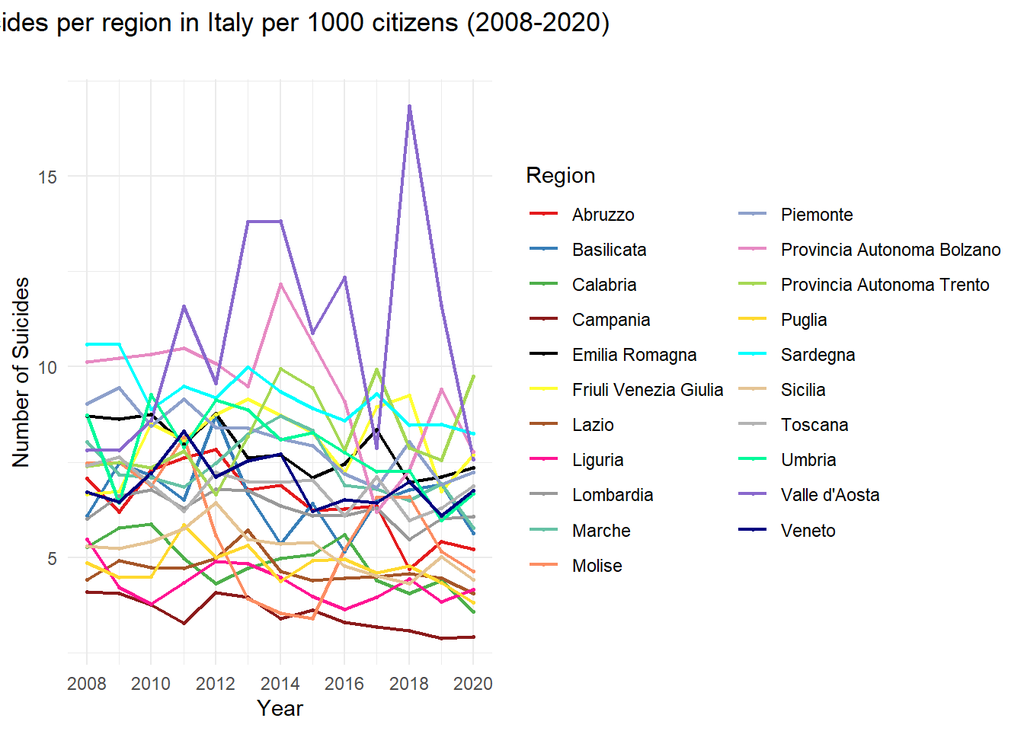

```r
# Ensure that TIME_PERIOD is numeric
data_italy$TIME_PERIOD <- as.numeric(data_italy$TIME_PERIOD)

# colour palette
palette <- c("#E41A1C", "#377EB8", "#4DAF4A", "firebrick4", "black",
             "#FFFF33", "#A65628", "deeppink1", "#999999", "#66C2A5",
             "#FC8D62", "#8DA0CB", "#E78AC3", "#A6D854", "#FFD92F","cyan1",
             "#E5C494", "#B3B3B3", "mediumspringgreen", "mediumpurple3","navyblue")

# Creating the graph
ggplot(data_italy, aes(x = TIME_PERIOD, y = suicides, color = CCAA)) +
  geom_line(size = 0.8) +  geom_point(size = 0.5) +
  scale_color_manual(values = palette) + scale_x_continuous(breaks = seq(min(data_italy$TIME_PERIOD), max(data_italy$TIME_PERIOD), by = 2)) +
  labs(title = "Suicides per region in Italy per 1000 citizens (2008-2020)",
       subtitle = "",
       x = "Year",
       y = "Number of Suicides",
       color = "Region") + # Labels and titles
  theme_minimal() + # Minimal theme
  theme(plot.title = element_text(hjust = 0.5),
        plot.subtitle = element_text(hjust = 0.5))
```

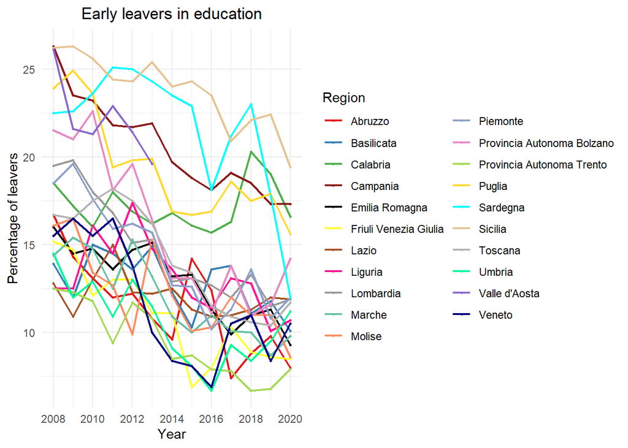

```r
# Definire una palette di colori manualmente
palette <- c("#E41A1C", "#377EB8", "#4DAF4A", "firebrick4", "black",
             "#FFFF33", "#A65628", "deeppink1", "#999999", "#66C2A5",
             "#FC8D62", "#8DA0CB", "#E78AC3", "#A6D854", "#FFD92F","cyan1",
             "#E5C494", "#B3B3B3", "mediumspringgreen", "mediumpurple3","navyblue")
# Creating the graph
ggplot(data_italy, aes(x = TIME_PERIOD, y = early_leaver_educ, color = CCAA)) +
  geom_line(size = 0.8) +
  geom_point(size = 0.5) +
  scale_color_manual(values = palette) + scale_x_continuous(breaks = seq(min(data_italy$TIME_PERIOD), max(data_italy$TIME_PERIOD), by = 2)) +
  labs(title = "Early leavers in education",
       x = "Year",
       y = "Percentage of leavers",
       color = "Region") + # Labels and titles
  theme_minimal() + # Minimal theme
  theme(plot.title = element_text(hjust = 0.5),
        plot.subtitle = element_text(hjust = 0.5))
```

```r
#getting geo data
italy <- ne_states(country = "Italy", returnclass = "sf")
 #Step 1: Identify unique values in each column
regions <- unique(italy$region)
ccaa <- unique(data_italy$CCAA)

 #Step 2: Create a mapping of CCAA to regions, including merging Bolzano and Trento into Trentino-Alto Adige
mapping <- c(
  "Piemonte"= "Piemonte",
  "Abruzzo" = "Abruzzo",
  "Basilicata" = "Basilicata",
  "Calabria" = "Calabria",
  "Campania" = "Campania",
  "Emilia Romagna" = "Emilia-Romagna",  # Rename to match `region`
  "Friuli Venezia Giulia" = "Friuli-Venezia Giulia",  # Rename to match `region`
  "Lazio" = "Lazio",
  "Liguria" = "Liguria",
  "Lombardia" = "Lombardia",
  "Marche" = "Marche",
  "Molise" = "Molise",
  "Provincia Autonoma Bolzano" = "Trentino-Alto Adige",  # Merge with Trentino-Alto Adige
  "Provincia Autonoma Trento" = "Trentino-Alto Adige",  # Merge with Trentino-Alto Adige
  "Puglia" = "Apulia",  # Rename to match `region`
  "Sardegna" = "Sardegna",
  "Sicilia" = "Sicily",  # Rename to match `region`
  "Toscana" = "Toscana",
  "Umbria" = "Umbria",
  "Valle d'Aosta" = "Valle d'Aosta",
  "Veneto" = "Veneto"

)

# Step 3: Apply the mapping to `data_italy$CCAA`
data_italy$CCAA <- mapping[data_italy$CCAA]

# Verify the changes
unique(data_italy$CCAA)
```

```
##  [1] "Abruzzo"               "Basilicata"            "Calabria"
##  [4] "Campania"              "Emilia-Romagna"        "Friuli-Venezia Giulia"
##  [7] "Lazio"                 "Liguria"               "Lombardia"
## [10] "Marche"                "Molise"                "Piemonte"
## [13] "Trentino-Alto Adige"   "Apulia"                "Sardegna"
## [16] "Sicily"                "Toscana"               "Umbria"
## [19] "Valle d'Aosta"         "Veneto"
```

```r
# Load geographical data
italy <- ne_states(country = "Italy", returnclass = "sf")

unique(italy$region)
```

```
##  [1] "Valle d'Aosta"         "Piemonte"              "Lombardia"
##  [4] "Trentino-Alto Adige"   "Liguria"               "Emilia-Romagna"
##  [7] "Marche"                "Veneto"                "Friuli-Venezia Giulia"
## [10] "Abruzzo"               "Molise"                "Apulia"
## [13] "Basilicata"            "Calabria"              "Campania"
## [16] "Lazio"                 "Toscana"               "Sicily"
## [19] "Sardegna"              "Umbria"
```

```r
unique(data_italy$CCAA)
```

```
##  [1] "Abruzzo"               "Basilicata"            "Calabria"
##  [4] "Campania"              "Emilia-Romagna"        "Friuli-Venezia Giulia"
##  [7] "Lazio"                 "Liguria"               "Lombardia"
## [10] "Marche"                "Molise"                "Piemonte"
## [13] "Trentino-Alto Adige"   "Apulia"                "Sardegna"
## [16] "Sicily"                "Toscana"               "Umbria"
## [19] "Valle d'Aosta"         "Veneto"
```

```r
# Filter the data
data_italy_filtered <- data_italy |>
  filter(TIME_PERIOD %in% c(2008, 2012, 2016, 2020))

# Select the necessary columns and remove duplicates
mapa <- data_italy_filtered |>
  select(CCAA, gender_gap_ind, TIME_PERIOD) |>
  distinct(CCAA, TIME_PERIOD, .keep_all = TRUE)

# Check if there are NA values in the TIME_PERIOD field before the join
print("Unique TIME_PERIOD values before join:")
```

```
## [1] "Unique TIME_PERIOD values before join:"
```

```r
print(unique(mapa$TIME_PERIOD))
```

```
## [1] 2008 2012 2016 2020
```

```r
# Join the geographical data with the gender gap data
mapa <- italy |>
  left_join(mapa, by = c("region" = "CCAA"))

# Check if there are NA values in the TIME_PERIOD field after the join
print("Unique TIME_PERIOD values after join:")
```

```
## [1] "Unique TIME_PERIOD values after join:"
```

```r
print(unique(mapa$TIME_PERIOD))
```

```
## [1] 2008 2012 2016 2020
```

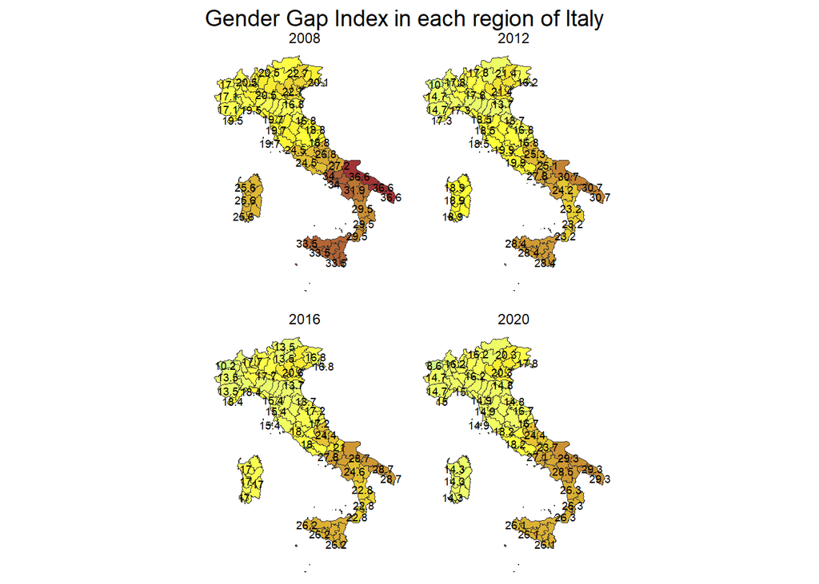

```r
# Filter the data again
mapa <- mapa |>
  filter(TIME_PERIOD %in% c(2008, 2012, 2016, 2020))

# Create the map
p1 <- ggplot() +
  geom_sf(data = italy, color = "black", size = 0.7) +
  geom_sf(data = mapa, aes(fill = gender_gap_ind), color = "black", size = 0.3) +
  annotate("rect", xmin = -Inf, xmax = Inf, ymin = -Inf, ymax = Inf, alpha = 0.2, fill = "white") +
  geom_sf_text(data = mapa, aes(label = round(gender_gap_ind, 2), color = ifelse(gender_gap_ind > 0.5, "black", "white")),
               size = 2.4, check_overlap = TRUE, nudge_y = -0.03) +
  theme_void() +
  labs(title = "Gender Gap Index in each region of Italy") +
  theme(
    legend.position = "none",
    plot.title = element_text(family = "Calibri", size = 14),
    text = element_text(family = "Calibri"),
    plot.background = element_rect(fill = "white", color = NA),
    panel.background = element_rect(fill = "white", color = NA)
  ) +
  coord_sf() +
  scale_fill_gradient2(low = "lightgreen", mid = "yellow", high = "darkred", midpoint = median(data_italy_filtered$gender_gap_ind, na.rm = TRUE)) +
  scale_color_identity() +
  facet_wrap(~ TIME_PERIOD, ncol = 2)

# Print the plot
print(p1)
```

```r
# Load geographical data
italy <- ne_states(country = "Italy", returnclass = "sf")

unique(italy$region)
```

```
##  [1] "Valle d'Aosta"         "Piemonte"              "Lombardia"
##  [4] "Trentino-Alto Adige"   "Liguria"               "Emilia-Romagna"
##  [7] "Marche"                "Veneto"                "Friuli-Venezia Giulia"
## [10] "Abruzzo"               "Molise"                "Apulia"
## [13] "Basilicata"            "Calabria"              "Campania"
## [16] "Lazio"                 "Toscana"               "Sicily"
## [19] "Sardegna"              "Umbria"
```

```r
unique(data_italy$CCAA)
```

```
##  [1] "Abruzzo"               "Basilicata"            "Calabria"
##  [4] "Campania"              "Emilia-Romagna"        "Friuli-Venezia Giulia"
##  [7] "Lazio"                 "Liguria"               "Lombardia"
## [10] "Marche"                "Molise"                "Piemonte"
## [13] "Trentino-Alto Adige"   "Apulia"                "Sardegna"
## [16] "Sicily"                "Toscana"               "Umbria"
## [19] "Valle d'Aosta"         "Veneto"
```

```r
# Filter the data for the periods of interest
data_italy_filtered <- data_italy |>
  filter(TIME_PERIOD %in% c(2008, 2012, 2016, 2020))

# Select the necessary columns and remove duplicates
mapa <- data_italy_filtered |>
  select(CCAA, suicides, TIME_PERIOD)  |>
  distinct(CCAA, TIME_PERIOD, .keep_all = TRUE)

# Check if there are NA values in the TIME_PERIOD field before the join
print("Unique TIME_PERIOD values before join:")
```

```
## [1] "Unique TIME_PERIOD values before join:"
```

```r
print(unique(mapa$TIME_PERIOD))
```

```
## [1] 2008 2012 2016 2020
```

```r
# Join the geographical data with the suicide data
mapa <- italy |>
  left_join(mapa, by = c("region" = "CCAA"))

# Check if there are NA values in the TIME_PERIOD field after the join
print("Unique TIME_PERIOD values after join:")
```

```
## [1] "Unique TIME_PERIOD values after join:"
```

```r
print(unique(mapa$TIME_PERIOD))
```

```
## [1] 2008 2012 2016 2020
```

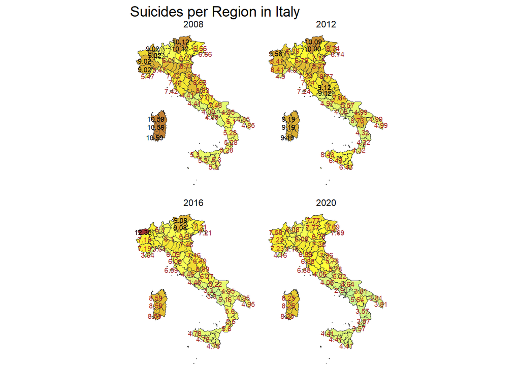

```r
# Filter the data again
mapa <- mapa |>
  filter(TIME_PERIOD %in% c(2008, 2012, 2016, 2020))

# Create the map
p1 <- ggplot() +
  geom_sf(data = italy, color = "black", size = 0.7) +
  geom_sf(data = mapa, aes(fill = suicides), color = "black", size = 0.3) +
  annotate("rect", xmin = -Inf, xmax = Inf, ymin = -Inf, ymax = Inf, alpha = 0.2, fill = "white") +
  geom_sf_text(data = mapa, aes(label = round(suicides, 2), color = ifelse(suicides > 9, "black", "brown")),
               size = 2.4, check_overlap = TRUE, nudge_y = -0.03) +
  theme_void() +
  labs(title = "Suicides per Region in Italy") +
  theme(
    legend.position = "none",
    plot.title = element_text(family = "Calibri", size = 14),
    text = element_text(family = "Calibri"),
    plot.background = element_rect(fill = "white", color = NA),
    panel.background = element_rect(fill = "white", color = NA)
  ) +
  coord_sf() +
  scale_fill_gradient2(low = "lightgreen", mid = "yellow", high = "darkred", midpoint = median(data_italy_filtered$suicides, na.rm = TRUE)) +
  scale_color_identity() +
  facet_wrap(~ TIME_PERIOD, ncol = 2)  # Create facets for TIME_PERIOD

# Print the plot
print(p1)
```

```r
# Load geographical data
italy <- ne_states(country = "Italy", returnclass = "sf")

unique(italy$region)
```

```
##  [1] "Valle d'Aosta"         "Piemonte"              "Lombardia"
##  [4] "Trentino-Alto Adige"   "Liguria"               "Emilia-Romagna"
##  [7] "Marche"                "Veneto"                "Friuli-Venezia Giulia"
## [10] "Abruzzo"               "Molise"                "Apulia"
## [13] "Basilicata"            "Calabria"              "Campania"
## [16] "Lazio"                 "Toscana"               "Sicily"
## [19] "Sardegna"              "Umbria"
```

```r
unique(data_italy$CCAA)
```

```
##  [1] "Abruzzo"               "Basilicata"            "Calabria"
##  [4] "Campania"              "Emilia-Romagna"        "Friuli-Venezia Giulia"
##  [7] "Lazio"                 "Liguria"               "Lombardia"
## [10] "Marche"                "Molise"                "Piemonte"
## [13] "Trentino-Alto Adige"   "Apulia"                "Sardegna"
## [16] "Sicily"                "Toscana"               "Umbria"
## [19] "Valle d'Aosta"         "Veneto"
```

```r
# Filter the data for the periods of interest
data_italy_filtered <- data_italy |>
  filter(TIME_PERIOD %in% c(2008, 2012, 2016, 2020))

# Select the necessary columns and remove duplicates
mapa <- data_italy_filtered |>
  select(CCAA, employment_value, TIME_PERIOD) |>
  distinct(CCAA, TIME_PERIOD, .keep_all = TRUE)

# Check if there are NA values in the TIME_PERIOD field before the join
print("Unique TIME_PERIOD values before join:")
```

```
## [1] "Unique TIME_PERIOD values before join:"
```

```r
print(unique(mapa$TIME_PERIOD))
```

```
## [1] 2008 2012 2016 2020
```

```r
# Join the geographical data with the employment data
mapa <- italy %>%
  left_join(mapa, by = c("region" = "CCAA"))

# Check if there are NA values in the TIME_PERIOD field after the join
print("Unique TIME_PERIOD values after join:")
```

```
## [1] "Unique TIME_PERIOD values after join:"
```

```r
print(unique(mapa$TIME_PERIOD))
```

```
## [1] 2008 2012 2016 2020
```

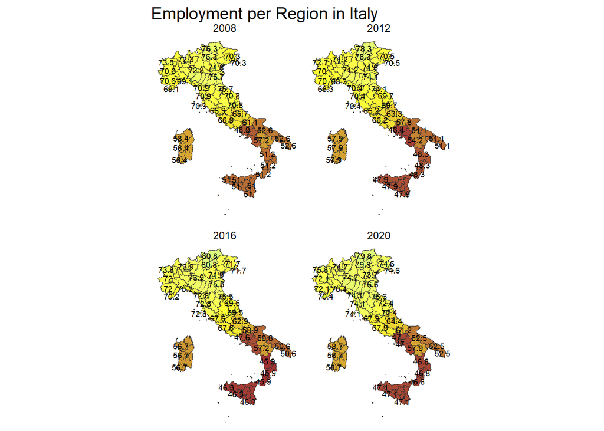

```r
# Filter the data again
mapa <- mapa |>
  filter(TIME_PERIOD %in% c(2008, 2012, 2016, 2020))

# Create the map
p1 <- ggplot() +
  geom_sf(data = italy, color = "black", size = 0.7) +
  geom_sf(data = mapa, aes(fill = employment_value), color = "black", size = 0.3) +
  annotate("rect", xmin = -Inf, xmax = Inf, ymin = -Inf, ymax = Inf, alpha = 0.2, fill = "white") +
  geom_sf_text(data = mapa, aes(label = round(employment_value, 2), color = ifelse(employment_value > 9, "black", "brown")),
               size = 2.4, check_overlap = TRUE, nudge_y = -0.03) +
  theme_void() +
  labs(title = "Employment per Region in Italy") +
  theme(
    legend.position = "none",
    plot.title = element_text(family = "Calibri", size = 14),
    text = element_text(family = "Calibri"),
    plot.background = element_rect(fill = "white", color = NA),
    panel.background = element_rect(fill = "white", color = NA)
  ) +
  coord_sf() +
  scale_fill_gradient2(low = "darkred", mid = "yellow", high = "lightgreen", midpoint = median(data_italy_filtered$employment_value, na.rm = TRUE)) +
  scale_color_identity() +
  facet_wrap(~ TIME_PERIOD, ncol = 2)  # Create facets for TIME_PERIOD

# Print the plot
print(p1)
```

the south is in a bad situation, and it’s very clear in the graph

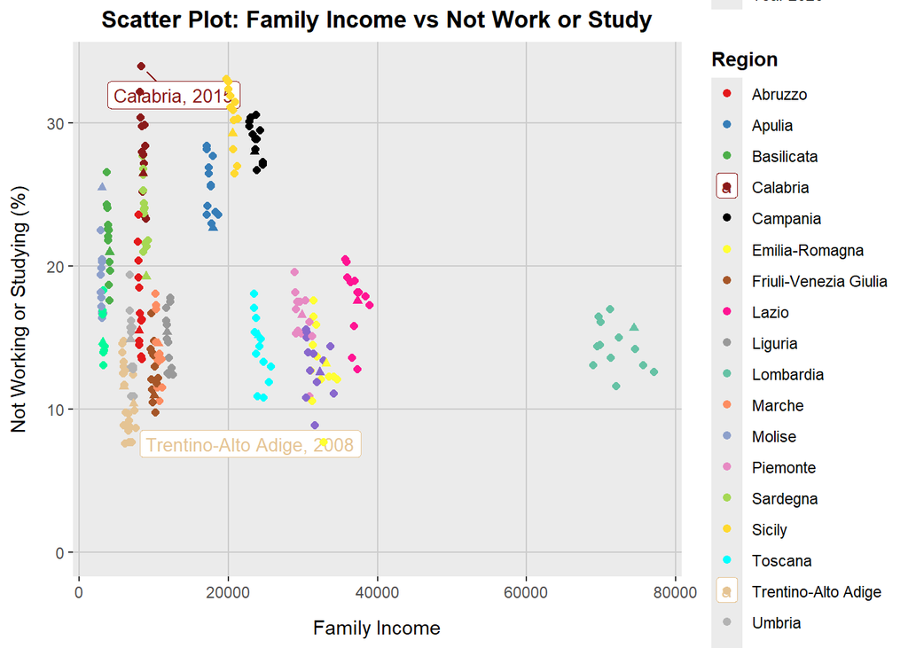

```r
# Create a new column to identify if the TIME_PERIOD is 2020 and label it appropriately
data_italy <- data_italy |>
  mutate(is_2020_label = ifelse(TIME_PERIOD == 2020, "Year 2020", "Other Years"))

# Filter out the extremes for labeling
highest <- data_italy |>
  filter(not_work_or_study == max(not_work_or_study, na.rm = TRUE))

lowest <- data_italy |>
  filter(not_work_or_study == min(not_work_or_study, na.rm = TRUE))

extremes <- rbind(highest, lowest)


scatter_plot <- ggplot(data_italy, aes(x = family_income, y = not_work_or_study, color = CCAA)) +
  geom_label_repel(data = extremes, aes(label = paste(CCAA, TIME_PERIOD, sep = ", ")), size = 3.5, box.padding = 0.5, point.padding = 0.5) +
  geom_point(aes(shape = is_2020_label), size = 1.7) +
  scale_shape_manual(values = c("Other Years" = 16, "Year 2020" = 17)) + # Use 16 (circle) for other years and 17 (triangle) for 2020
  scale_color_manual(values = palette) + # Use the custom defined palette
  scale_y_continuous(limits = c(0, NA), breaks = seq(0, max(data_italy$not_work_or_study, na.rm = TRUE), by = 10)) +
  # The above line sets the lower limit to 0 and automatically adjusts the upper limit based on the data
  labs(title = "Scatter Plot: Family Income vs Not Work or Study",
       x = "Family Income",
       y = "Not Working or Studying (%)",
       color = "Region",
       shape = "Year") + # Update the legend title for shapes
  theme(
    plot.title = element_text(hjust = 0.5, face = "bold"),
    legend.position = "right",
    legend.title = element_text(face = "bold"),
    panel.grid.major = element_line(color = "grey80"),
    panel.grid.minor = element_blank(),
    axis.title.x = element_text(margin = margin(t = 10)),
    axis.title.y = element_text(margin = margin(r = 10))
  )

# Display the plot with the adjusted y-axis
scatter_plot
```